# Risk Factor Analysis

## Outcome Variable

**Outcome Variable:** sstunted

## Predictor Variables

**Intervention Variable:** fhtcm

**Adjustment Set:**

- arm
- W_mage
- W_fage
- meducyrs
- feducyrs
- W_mhtcm
- W_mwtkg
- W_mbmi
- single
- delta_W_mage
- delta_W_fage
- delta_meducyrs
- delta_feducyrs
- delta_W_mhtcm
- delta_W_mwtkg
- delta_W_mbmi
- delta_single

## Stratifying Variables

The analysis was stratified on these variable(s):

- agecat
- studyid
- country

## Data Summary

| agecat | studyid | country | fhtcm | sstunted | n_cell | n |
| --- | --- | --- | --- | --- | --- | --- |
| Birth | ki1000304b-SAS-CompFeed | INDIA | >=167 cm | 0 | 49 | 102 |
| Birth | ki1000304b-SAS-CompFeed | INDIA | >=167 cm | 1 | 1 | 102 |
| Birth | ki1000304b-SAS-CompFeed | INDIA | <162 cm | 0 | 22 | 102 |
| Birth | ki1000304b-SAS-CompFeed | INDIA | <162 cm | 1 | 1 | 102 |
| Birth | ki1000304b-SAS-CompFeed | INDIA | [162-167) cm | 0 | 26 | 102 |
| Birth | ki1000304b-SAS-CompFeed | INDIA | [162-167) cm | 1 | 3 | 102 |
| Birth | ki1101329-Keneba | GAMBIA | >=167 cm | 0 | 755 | 1165 |
| Birth | ki1101329-Keneba | GAMBIA | >=167 cm | 1 | 17 | 1165 |
| Birth | ki1101329-Keneba | GAMBIA | <162 cm | 0 | 87 | 1165 |
| Birth | ki1101329-Keneba | GAMBIA | <162 cm | 1 | 0 | 1165 |
| Birth | ki1101329-Keneba | GAMBIA | [162-167) cm | 0 | 302 | 1165 |
| Birth | ki1101329-Keneba | GAMBIA | [162-167) cm | 1 | 4 | 1165 |
| Birth | ki1119695-PROBIT | BELARUS | >=167 cm | 0 | 11736 | 12533 |
| Birth | ki1119695-PROBIT | BELARUS | >=167 cm | 1 | 4 | 12533 |
| Birth | ki1119695-PROBIT | BELARUS | <162 cm | 0 | 168 | 12533 |
| Birth | ki1119695-PROBIT | BELARUS | <162 cm | 1 | 0 | 12533 |
| Birth | ki1119695-PROBIT | BELARUS | [162-167) cm | 0 | 624 | 12533 |
| Birth | ki1119695-PROBIT | BELARUS | [162-167) cm | 1 | 1 | 12533 |
| Birth | ki1135781-COHORTS | GUATEMALA | >=167 cm | 0 | 27 | 206 |
| Birth | ki1135781-COHORTS | GUATEMALA | >=167 cm | 1 | 2 | 206 |
| Birth | ki1135781-COHORTS | GUATEMALA | <162 cm | 0 | 119 | 206 |
| Birth | ki1135781-COHORTS | GUATEMALA | <162 cm | 1 | 2 | 206 |
| Birth | ki1135781-COHORTS | GUATEMALA | [162-167) cm | 0 | 56 | 206 |
| Birth | ki1135781-COHORTS | GUATEMALA | [162-167) cm | 1 | 0 | 206 |
| 6 months | ki1000304b-SAS-CompFeed | INDIA | >=167 cm | 0 | 345 | 807 |
| 6 months | ki1000304b-SAS-CompFeed | INDIA | >=167 cm | 1 | 24 | 807 |
| 6 months | ki1000304b-SAS-CompFeed | INDIA | <162 cm | 0 | 163 | 807 |
| 6 months | ki1000304b-SAS-CompFeed | INDIA | <162 cm | 1 | 31 | 807 |
| 6 months | ki1000304b-SAS-CompFeed | INDIA | [162-167) cm | 0 | 220 | 807 |
| 6 months | ki1000304b-SAS-CompFeed | INDIA | [162-167) cm | 1 | 24 | 807 |
| 6 months | ki1000304b-SAS-FoodSuppl | INDIA | >=167 cm | 0 | 91 | 372 |
| 6 months | ki1000304b-SAS-FoodSuppl | INDIA | >=167 cm | 1 | 11 | 372 |
| 6 months | ki1000304b-SAS-FoodSuppl | INDIA | <162 cm | 0 | 125 | 372 |
| 6 months | ki1000304b-SAS-FoodSuppl | INDIA | <162 cm | 1 | 23 | 372 |
| 6 months | ki1000304b-SAS-FoodSuppl | INDIA | [162-167) cm | 0 | 105 | 372 |
| 6 months | ki1000304b-SAS-FoodSuppl | INDIA | [162-167) cm | 1 | 17 | 372 |
| 6 months | ki1101329-Keneba | GAMBIA | >=167 cm | 0 | 948 | 1511 |
| 6 months | ki1101329-Keneba | GAMBIA | >=167 cm | 1 | 31 | 1511 |
| 6 months | ki1101329-Keneba | GAMBIA | <162 cm | 0 | 111 | 1511 |
| 6 months | ki1101329-Keneba | GAMBIA | <162 cm | 1 | 2 | 1511 |
| 6 months | ki1101329-Keneba | GAMBIA | [162-167) cm | 0 | 403 | 1511 |
| 6 months | ki1101329-Keneba | GAMBIA | [162-167) cm | 1 | 16 | 1511 |
| 6 months | ki1119695-PROBIT | BELARUS | >=167 cm | 0 | 11012 | 11895 |
| 6 months | ki1119695-PROBIT | BELARUS | >=167 cm | 1 | 134 | 11895 |
| 6 months | ki1119695-PROBIT | BELARUS | <162 cm | 0 | 147 | 11895 |
| 6 months | ki1119695-PROBIT | BELARUS | <162 cm | 1 | 9 | 11895 |
| 6 months | ki1119695-PROBIT | BELARUS | [162-167) cm | 0 | 578 | 11895 |
| 6 months | ki1119695-PROBIT | BELARUS | [162-167) cm | 1 | 15 | 11895 |
| 6 months | ki1135781-COHORTS | GUATEMALA | >=167 cm | 0 | 42 | 336 |
| 6 months | ki1135781-COHORTS | GUATEMALA | >=167 cm | 1 | 3 | 336 |
| 6 months | ki1135781-COHORTS | GUATEMALA | <162 cm | 0 | 157 | 336 |
| 6 months | ki1135781-COHORTS | GUATEMALA | <162 cm | 1 | 40 | 336 |
| 6 months | ki1135781-COHORTS | GUATEMALA | [162-167) cm | 0 | 85 | 336 |
| 6 months | ki1135781-COHORTS | GUATEMALA | [162-167) cm | 1 | 9 | 336 |
| 24 months | ki1101329-Keneba | GAMBIA | >=167 cm | 0 | 765 | 1297 |
| 24 months | ki1101329-Keneba | GAMBIA | >=167 cm | 1 | 56 | 1297 |
| 24 months | ki1101329-Keneba | GAMBIA | <162 cm | 0 | 88 | 1297 |
| 24 months | ki1101329-Keneba | GAMBIA | <162 cm | 1 | 9 | 1297 |
| 24 months | ki1101329-Keneba | GAMBIA | [162-167) cm | 0 | 340 | 1297 |
| 24 months | ki1101329-Keneba | GAMBIA | [162-167) cm | 1 | 39 | 1297 |
| 24 months | ki1119695-PROBIT | BELARUS | >=167 cm | 0 | 3395 | 3670 |
| 24 months | ki1119695-PROBIT | BELARUS | >=167 cm | 1 | 50 | 3670 |
| 24 months | ki1119695-PROBIT | BELARUS | <162 cm | 0 | 47 | 3670 |
| 24 months | ki1119695-PROBIT | BELARUS | <162 cm | 1 | 6 | 3670 |
| 24 months | ki1119695-PROBIT | BELARUS | [162-167) cm | 0 | 167 | 3670 |
| 24 months | ki1119695-PROBIT | BELARUS | [162-167) cm | 1 | 5 | 3670 |
| 24 months | ki1135781-COHORTS | GUATEMALA | >=167 cm | 0 | 49 | 528 |
| 24 months | ki1135781-COHORTS | GUATEMALA | >=167 cm | 1 | 23 | 528 |
| 24 months | ki1135781-COHORTS | GUATEMALA | <162 cm | 0 | 161 | 528 |
| 24 months | ki1135781-COHORTS | GUATEMALA | <162 cm | 1 | 146 | 528 |
| 24 months | ki1135781-COHORTS | GUATEMALA | [162-167) cm | 0 | 95 | 528 |
| 24 months | ki1135781-COHORTS | GUATEMALA | [162-167) cm | 1 | 54 | 528 |

The following strata were considered:

- agecat: 24 months, studyid: ki1101329-Keneba, country: GAMBIA
- agecat: 24 months, studyid: ki1119695-PROBIT, country: BELARUS
- agecat: 24 months, studyid: ki1135781-COHORTS, country: GUATEMALA
- agecat: 6 months, studyid: ki1000304b-SAS-CompFeed, country: INDIA
- agecat: 6 months, studyid: ki1000304b-SAS-FoodSuppl, country: INDIA
- agecat: 6 months, studyid: ki1101329-Keneba, country: GAMBIA
- agecat: 6 months, studyid: ki1119695-PROBIT, country: BELARUS
- agecat: 6 months, studyid: ki1135781-COHORTS, country: GUATEMALA
- agecat: Birth, studyid: ki1000304b-SAS-CompFeed, country: INDIA
- agecat: Birth, studyid: ki1101329-Keneba, country: GAMBIA
- agecat: Birth, studyid: ki1119695-PROBIT, country: BELARUS
- agecat: Birth, studyid: ki1135781-COHORTS, country: GUATEMALA

### Dropped Strata

Some strata were dropped due to rare outcomes:

- agecat: Birth, studyid: ki1000304b-SAS-CompFeed, country: INDIA
- agecat: Birth, studyid: ki1101329-Keneba, country: GAMBIA
- agecat: Birth, studyid: ki1119695-PROBIT, country: BELARUS
- agecat: Birth, studyid: ki1135781-COHORTS, country: GUATEMALA
- agecat: 6 months, studyid: ki1101329-Keneba, country: GAMBIA
- agecat: 6 months, studyid: ki1135781-COHORTS, country: GUATEMALA

## Methods Detail

We’re interested in the causal parameters $E[Y_a]$ for all values of $a \in \mathcal{A}$. These parameters represent the mean outcome if, possibly contrary to fact, we intervened to set all units to have $A=a$. Under the randomization and positivity assumptions, these are identified by the statistical parameters $\psi_a=E_W[E_{Y|A,W}(Y|A=a,W)]$. In addition, we’re interested in the mean of $Y$, $E[Y]$ under no intervention (the observed mean). We will estimate these parameters by using SuperLearner to fit the relevant likelihood factors – $E_{Y|A,W}(Y|A=a,W)$ and $p(A=a|W)$, and then updating our likelihood fit using a joint TMLE.

For unadjusted analyses ($W=\{\}$), initial likelihoods were estimated using Lrnr_glm to estimate the simple $E(Y|A)$ and Lrnr_mean to estimate $p(A)$. For adjusted analyses, a small library containing Lrnr_glmnet, Lrnr_xgboost, and Lrnr_mean was used.

Having estimated these parameters, we will then use the delta method to estimate relative risks and attributable risks relative to a prespecified baseline level of $A$.

# Results Detail

## Results Plots

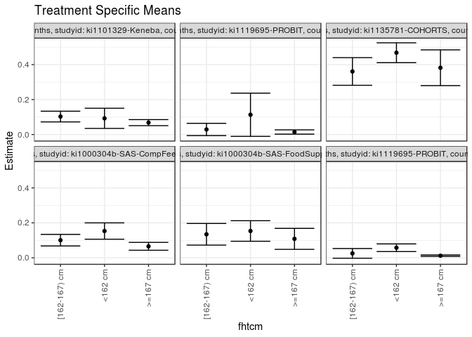

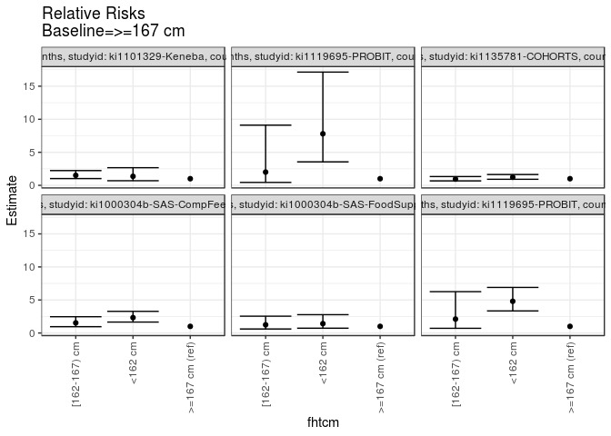

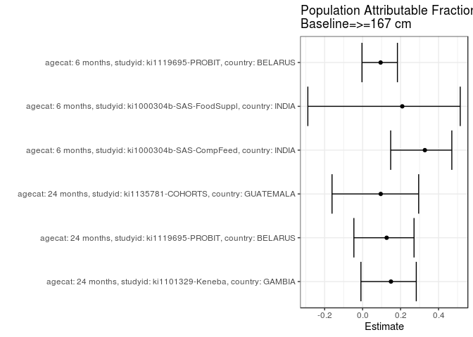

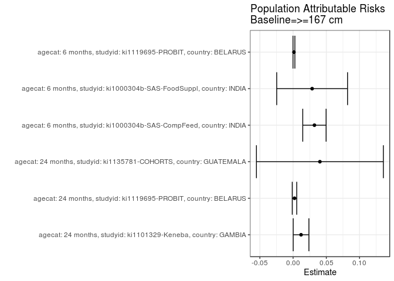

## Results Table

### Parameter: TSM

| agecat | studyid | country | intervention_level | baseline_level | estimate | ci_lower | ci_upper |
| --- | --- | --- | --- | --- | --- | --- | --- |
| 6 months | ki1000304b-SAS-CompFeed | INDIA | >=167 cm | NA | 0.0657884 | 0.0432806 | 0.0882963 |
| 6 months | ki1000304b-SAS-CompFeed | INDIA | <162 cm | NA | 0.1531390 | 0.1064535 | 0.1998244 |
| 6 months | ki1000304b-SAS-CompFeed | INDIA | [162-167) cm | NA | 0.1008444 | 0.0677743 | 0.1339145 |
| 6 months | ki1000304b-SAS-FoodSuppl | INDIA | >=167 cm | NA | 0.1084541 | 0.0484170 | 0.1684911 |
| 6 months | ki1000304b-SAS-FoodSuppl | INDIA | <162 cm | NA | 0.1534747 | 0.0947623 | 0.2121871 |
| 6 months | ki1000304b-SAS-FoodSuppl | INDIA | [162-167) cm | NA | 0.1345594 | 0.0727514 | 0.1963674 |
| 6 months | ki1119695-PROBIT | BELARUS | >=167 cm | NA | 0.0120223 | 0.0079019 | 0.0161426 |
| 6 months | ki1119695-PROBIT | BELARUS | <162 cm | NA | 0.0576923 | 0.0358042 | 0.0795804 |
| 6 months | ki1119695-PROBIT | BELARUS | [162-167) cm | NA | 0.0252951 | -0.0025152 | 0.0531054 |
| 24 months | ki1101329-Keneba | GAMBIA | >=167 cm | NA | 0.0682095 | 0.0509581 | 0.0854609 |
| 24 months | ki1101329-Keneba | GAMBIA | <162 cm | NA | 0.0927835 | 0.0350244 | 0.1505426 |
| 24 months | ki1101329-Keneba | GAMBIA | [162-167) cm | NA | 0.1029024 | 0.0723019 | 0.1335029 |
| 24 months | ki1119695-PROBIT | BELARUS | >=167 cm | NA | 0.0145138 | 0.0022992 | 0.0267283 |
| 24 months | ki1119695-PROBIT | BELARUS | <162 cm | NA | 0.1132075 | -0.0103712 | 0.2367863 |
| 24 months | ki1119695-PROBIT | BELARUS | [162-167) cm | NA | 0.0290698 | -0.0059881 | 0.0641276 |
| 24 months | ki1135781-COHORTS | GUATEMALA | >=167 cm | NA | 0.3820131 | 0.2798525 | 0.4841737 |
| 24 months | ki1135781-COHORTS | GUATEMALA | <162 cm | NA | 0.4678846 | 0.4110861 | 0.5246831 |
| 24 months | ki1135781-COHORTS | GUATEMALA | [162-167) cm | NA | 0.3607444 | 0.2817050 | 0.4397838 |

### Parameter: E(Y)

| agecat | studyid | country | intervention_level | baseline_level | estimate | ci_lower | ci_upper |
| --- | --- | --- | --- | --- | --- | --- | --- |
| 6 months | ki1000304b-SAS-CompFeed | INDIA | NA | NA | 0.0978934 | 0.0736377 | 0.1221492 |
| 6 months | ki1000304b-SAS-FoodSuppl | INDIA | NA | NA | 0.1370968 | 0.1020978 | 0.1720958 |
| 6 months | ki1119695-PROBIT | BELARUS | NA | NA | 0.0132829 | 0.0086021 | 0.0179637 |
| 24 months | ki1101329-Keneba | GAMBIA | NA | NA | 0.0801850 | 0.0653993 | 0.0949708 |
| 24 months | ki1119695-PROBIT | BELARUS | NA | NA | 0.0166213 | 0.0025092 | 0.0307333 |
| 24 months | ki1135781-COHORTS | GUATEMALA | NA | NA | 0.4223485 | 0.3801777 | 0.4645192 |

### Parameter: RR

| agecat | studyid | country | intervention_level | baseline_level | estimate | ci_lower | ci_upper |
| --- | --- | --- | --- | --- | --- | --- | --- |
| 6 months | ki1000304b-SAS-CompFeed | INDIA | >=167 cm | >=167 cm | 1.0000000 | 1.0000000 | 1.000000 |
| 6 months | ki1000304b-SAS-CompFeed | INDIA | <162 cm | >=167 cm | 2.3277489 | 1.6538780 | 3.276188 |
| 6 months | ki1000304b-SAS-CompFeed | INDIA | [162-167) cm | >=167 cm | 1.5328589 | 0.9545336 | 2.461575 |
| 6 months | ki1000304b-SAS-FoodSuppl | INDIA | >=167 cm | >=167 cm | 1.0000000 | 1.0000000 | 1.000000 |
| 6 months | ki1000304b-SAS-FoodSuppl | INDIA | <162 cm | >=167 cm | 1.4151127 | 0.7228985 | 2.770159 |
| 6 months | ki1000304b-SAS-FoodSuppl | INDIA | [162-167) cm | >=167 cm | 1.2407039 | 0.6060025 | 2.540165 |
| 6 months | ki1119695-PROBIT | BELARUS | >=167 cm | >=167 cm | 1.0000000 | 1.0000000 | 1.000000 |
| 6 months | ki1119695-PROBIT | BELARUS | <162 cm | >=167 cm | 4.7987945 | 3.3403900 | 6.893934 |
| 6 months | ki1119695-PROBIT | BELARUS | [162-167) cm | >=167 cm | 2.1040246 | 0.7075144 | 6.257003 |
| 24 months | ki1101329-Keneba | GAMBIA | >=167 cm | >=167 cm | 1.0000000 | 1.0000000 | 1.000000 |
| 24 months | ki1101329-Keneba | GAMBIA | <162 cm | >=167 cm | 1.3602725 | 0.6947196 | 2.663436 |
| 24 months | ki1101329-Keneba | GAMBIA | [162-167) cm | >=167 cm | 1.5086223 | 1.0210316 | 2.229061 |
| 24 months | ki1119695-PROBIT | BELARUS | >=167 cm | >=167 cm | 1.0000000 | 1.0000000 | 1.000000 |
| 24 months | ki1119695-PROBIT | BELARUS | <162 cm | >=167 cm | 7.8000000 | 3.5504170 | 17.136015 |
| 24 months | ki1119695-PROBIT | BELARUS | [162-167) cm | >=167 cm | 2.0029070 | 0.4406297 | 9.104326 |
| 24 months | ki1135781-COHORTS | GUATEMALA | >=167 cm | >=167 cm | 1.0000000 | 1.0000000 | 1.000000 |
| 24 months | ki1135781-COHORTS | GUATEMALA | <162 cm | >=167 cm | 1.2247870 | 0.9170900 | 1.635721 |
| 24 months | ki1135781-COHORTS | GUATEMALA | [162-167) cm | >=167 cm | 0.9443248 | 0.6714122 | 1.328170 |

### Parameter: PAR

| agecat | studyid | country | intervention_level | baseline_level | estimate | ci_lower | ci_upper |
| --- | --- | --- | --- | --- | --- | --- | --- |
| 6 months | ki1000304b-SAS-CompFeed | INDIA | >=167 cm | NA | 0.0321050 | 0.0145389 | 0.0496710 |
| 6 months | ki1000304b-SAS-FoodSuppl | INDIA | >=167 cm | NA | 0.0286427 | -0.0246600 | 0.0819455 |
| 6 months | ki1119695-PROBIT | BELARUS | >=167 cm | NA | 0.0012606 | -0.0001507 | 0.0026720 |
| 24 months | ki1101329-Keneba | GAMBIA | >=167 cm | NA | 0.0119755 | 0.0001665 | 0.0237846 |
| 24 months | ki1119695-PROBIT | BELARUS | >=167 cm | NA | 0.0021075 | -0.0012752 | 0.0054902 |
| 24 months | ki1135781-COHORTS | GUATEMALA | >=167 cm | NA | 0.0403354 | -0.0551812 | 0.1358521 |

### Parameter: PAF

| agecat | studyid | country | intervention_level | baseline_level | estimate | ci_lower | ci_upper |
| --- | --- | --- | --- | --- | --- | --- | --- |
| 6 months | ki1000304b-SAS-CompFeed | INDIA | >=167 cm | NA | 0.3279586 | 0.1479214 | 0.4699555 |
| 6 months | ki1000304b-SAS-FoodSuppl | INDIA | >=167 cm | NA | 0.2089234 | -0.2883792 | 0.5142717 |
| 6 months | ki1119695-PROBIT | BELARUS | >=167 cm | NA | 0.0949072 | -0.0032410 | 0.1834534 |
| 24 months | ki1101329-Keneba | GAMBIA | >=167 cm | NA | 0.1493488 | -0.0088168 | 0.2827167 |
| 24 months | ki1119695-PROBIT | BELARUS | >=167 cm | NA | 0.1267934 | -0.0458934 | 0.2709680 |
| 24 months | ki1135781-COHORTS | GUATEMALA | >=167 cm | NA | 0.0955027 | -0.1609893 | 0.2953291 |